# Ficha 244

Áreas Prioritárias do Cerrado e Pantanal · 2ª atualização · Ficha de estado e dinâmica 2012–2025

## Curvelo código 244

**UF**

MG

**Área**

47.564 ha

**Bioma (IBGE 2019)**

Cerrado 100%

**Importância biológica**

Muito Alta

**Prioridade de ação**

Alta

**Ações**

Recuperação; Fomento ao uso sustentável

Estado em 2025 33% 20–50% de vegetação natural · 15.533 ha

Dinâmica 2012–2025 Ganho líquido +0,54 ± 0,10%/ano · tendência > +0,2%/ano, com ganho ≥ 0,5 p.p. da área e ≥ 100 ha

Principal vetor de conversão pastagem 58% da vegetação convertida entre 2012 e 2025

Nenhum alerta.

### Mapa de mudanças 2012–2025

Comparação dos grupos de nível 1 do MapBiomas em 2012 e 2025. A área está em cores plenas e contornada; o entorno aparece esmaecido, como contexto. O mapa é ilustrativo, em coordenadas geográficas, com escala aproximada; as áreas da legenda vêm das tabelas.

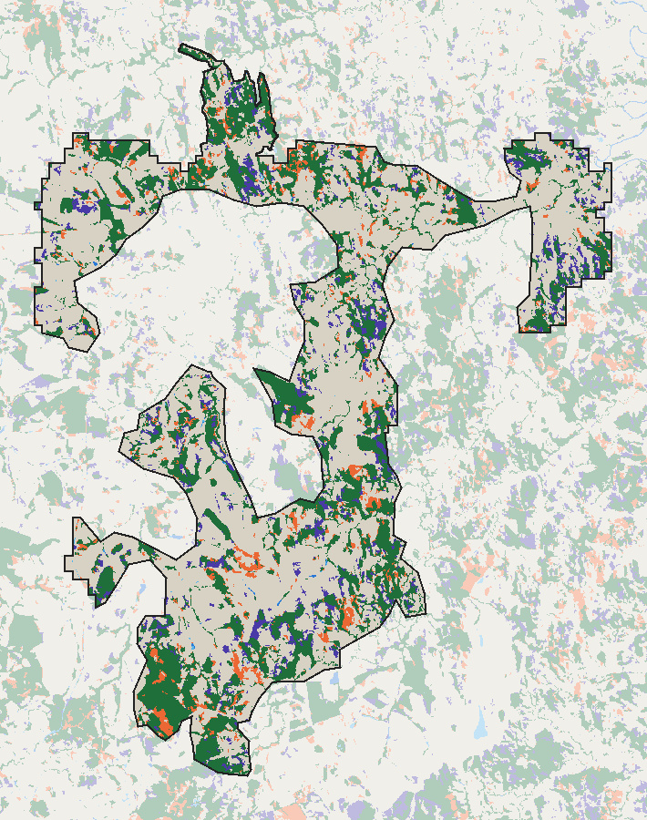

5 km

- Vegetação natural estável12.792 ha · 26,9%
- Perda de vegetação natural2.237 ha · 4,7%
- Ganho de vegetação natural2.739 ha · 5,8%
- Uso antrópico estável29.696 ha · 62,4%
- Água ou areia estável44 ha · 0,1%
- Trocas com água ou areia53 ha · 0,1%

### Trajetória da área não convertida

Vegetação natural mais água e areia, índice 2012 = 100: é a base da categoria. A linha tracejada é a matriz fora das áreas prioritárias no bioma Cerrado, como **contexto**; não é uma avaliação de efeito.

[figure not shown]

|  | 2012–2025 | 2012–2018 | 2018–2025 | Matriz do bioma 2012–2025 |
| --- | --- | --- | --- | --- |
| Tendência líquida (%/ano da vegetação de 2012) | +0,54 | +0,14 | +0,47 | −0,77 |
| Conversão bruta (%/ano) | 2,02 |  |  | 1,33 |
| Regeneração bruta (%/ano) | 2,27 |  |  | 0,45 |

### Composição da paisagem (ha)

|  | 2012 | 2025 | Variação |
| --- | --- | --- | --- |
| Vegetação natural | 15.036 | 15.533 | +497 |
| Formação florestal | 6.753 | 6.837 | +83 |
| Formação savânica | 4.837 | 6.112 | +1.275 |
| Formação campestre | 3.062 | 2.331 | −731 |
| Campo alagado | 383 | 254 | −129 |
| Uso antrópico | 32.472 | 31.942 | −530 |
| Pastagem | 25.885 | 21.815 | −4.069 |
| Soja | 0 | 56 | +56 |
| Outras lavouras | 97 | 366 | +269 |
| Mosaico de usos | 3.173 | 4.386 | +1.213 |
| Silvicultura | 2.794 | 4.675 | +1.882 |
| Urbano, mineração e outros | 524 | 643 | +119 |
| Natural não vegetado | 54 | 87 | +33 |
| Água | 54 | 87 | +33 |

Vegetação natural: 31,6% da área terrestre em 2012 e 32,7% em 2025.

Dinâmica hidrológica (fora da contabilidade): 7 ha de vegetação natural de 2012 eram água ou areia em 2025, e 2 ha fizeram o caminho inverso. Vegetação que virou água e ficou água em 2020–2025 (possível reservatório): 2 ha.

### Persistência

| Vegetação natural de 2012 nunca convertida em uso até 2025 | 12.283 ha | 81,7% |
| --- | --- | --- |
| Vegetação natural de 1985 nunca convertida em uso até 2025 | 7.879 ha | 42,6% |
| Parcela da vegetação natural de 2025 nunca convertida desde 1985 |  | 50,7% |

A diferença entre a vegetação de 2025 e a vegetação nunca convertida é vegetação secundária ou regenerada, que conta como natural no MapBiomas.

### Fogo na vegetação natural estável, 1985–2025

Vegetação que permaneceu natural em todos os anos de 1985 a 2025: savana e campo estáveis somam 3.085 ha e floresta estável 4.453 ha. Savana e campo: **acima do esperado** = fogo repetido com intervalos menores que 3 anos (ao menos dois); **abaixo do esperado** = nenhum fogo nos últimos 20 anos (2006–2025), incluindo o que nunca queimou; **de acordo** = os demais casos, que não são uma afirmação de adequação. Floresta: qualquer fogo é afetação. Os dados são apresentados sem juízo de mérito ou de causa.

Acima do esperado · floresta afetadaDe acordo · floresta não afetadaAbaixo do esperado· barras esmaecidas: matriz

[figure not shown]

Matriz = vegetação estável do Cerrado e do Pantanal fora das áreas prioritárias, como contexto. Áreas úmidas (campo e savana alagáveis): mesma regra, só reportada, sem leitura de categoria, porque o regime depende da inundação.

- **Abaixo do esperado em 97%** da savana e do campo estáveis — robusto: mantém-se acima de 50% com limiar de 25 anos (96%).

#### Mudança entre 2012–2018 e 2019–2025 (savana e campo estáveis)

|  | 2012–2018 | 2019–2025 | Matriz ao sul de 18°S 2012–2018 · 2019–2025 |
| --- | --- | --- | --- |
| Área queimada por ano (% da área estável) | 0,1% | 0,1% |  |
| Área com fogo em anos consecutivos (% da área estável) | 0,0% | 0,0% |  |
| **Fogo em julho–agosto** (% do queimado) | **–** | **–** | 22% · 41% |
| Fogo na janela crítica, julho–setembro (% do queimado; descritor) | – | – | 66% · 71% |

“–” nas razões sazonais: fogo insuficiente no subperíodo (menos de 1.000 ha ou de 1% da vegetação aberta estável).

Julho e agosto são meses sem raios no Cerrado: o fogo nesses meses é iniciado por pessoas. A janela crítica marca o período de maior estresse hídrico da faixa de latitude e é mostrada só como descritor, porque o sentido da sua mudança depende de onde cai o limite da janela. Método: decisão D15 do projeto.

### Alvos de conservação da área (2ª atualização, listas de 2011–2012)

| Grupo | Alvos |
| --- | --- |
| Plantas | 58 |
| Répteis | 13 |
| Mamíferos | 11 |
| Aves | 5 |
| Sistemas de terras | 1 |

**Lista de alvos**

- **Aves:** Alectrurus tricolor, Alipiopsitta xanthops, Coryphaspiza melanotis, Poospiza cinerea, Taoniscus nanus
- **Mamíferos:** Carterodon sulcidens, Chrysocyon brachyurus, Clyomys laticeps, Cuniculus paca, Myrmechophaga tridactyla, Ozotoceros bezoarticus, Panthera onca, Priodontes maximus, Puma concolor, Tapirus terrestris, Tayassu pecari
- **Plantas:** Anacardium humile a.st.-hil., Anemopaegma arvense (vell.) stellfeld ex de souza, Aspidosperma camporum mpll.arg., Astraea lobata (l.) klotzsch, Astronium fraxinifolium schott, Astronium graveolens jacq., Callisthene major mart. & zucc., Camarea ericoides a.st.-hil., Campomanesia pubescens (dc.) o.berg, Carpotroche brasiliensis (raddi) endl., Chrysolaena obovata (less.) dematt., Chrysolaena simplex (less.) dematt., Cochlospermum insigne a.st.-hil., Dasyphyllum brasiliense var. latifolium (d.don) c*, Dipteryx alata vogel, Dyckia minarum mez, Eremanthus glomerulatus less., Eugenia aurata o.berg, Eugenia dysenterica dc., Eugenia punicifolia (hbk) dc., Ficus eximia schott, Galactia glaucescens kunth, Gaya domingensis urb., Guadua paniculata munro, Handroanthus impetiginosus mattos, Handroanthus ochraceus (cham.) mattos, Inga fagifolia willd. ex benth, Jacaranda brasiliana (lam.) pers., Jacaranda caroba (vell.) dc., Jacaranda decurrens cham., Lessingianthus bardanoides (less.) h.rob., Lessingianthus virgulatus (mart. ex dc.) h.rob., Mandevilla hirsuta (a.rich.) k.schum., Myracrodruon urundeuva allem.o, Myrcia tomentosa (aubl.) dc., Myrcia uberavensis o.berg, Myrsine guianensis (aubl.) kuntze, Ocotea pulchella (nees & mart.) mez, Pfaffia jubata mart., Pfaffia minarum pedersen, Piptocarpha rotundifolia (less.) baker, Psidium myrsinites dc., Pterandra pyroidea a.juss., Qualea dichotoma (mart.) warm., Qualea grandiflora mart., Qualea jundiahy warm., Qualea multiflora mart., Qualea parviflora mart., Rhynchanthera grandiflora (aubl.) dc., Salvertia convallariodora a.st.-hil., Tabebuia aurea (silva manso) benth. & hook.f. ex *, Tabebuia roseoalba (ridl.) sandwith, Vernonanthura ferruginea (less.) h.rob., Vernonia desertorum mart., Vernonia rubriramea mart. ex dc., Vochysia tucanorum mart., Xylopia aromatica (lam.) mart., Zeyheria digitalis (vell.) hoehne & kuhlm.
- **Répteis:** Apostolepis flavotorquata, Atractus pantostictus, Chironius flavolineatus, Chironius quadricarinatus, Drymoluber brazili, Epicrates crassus, Hoplocercus spinosus, Micrablepharus atticolus, Phalotris nasutus, Phimophis guerini, Tropidurus itambere, Tropidurus montanus, Xenodon nattereri
- **Sistemas de terras:** 1cc1n

As listas são históricas e não representam a lista vigente de espécies ameaçadas.